Skip to main content

# Micro- and Nanoplastics: Crossing the Blood-Brain Barrier to Drive Sustained Neuroinflammation and HPA Axis Dysregulation

Author

Affiliation

Tran Quoc Hoang

International University - VNU-HCM

Published

11-26-2026

Abstract

The ubiquitous presence of micro- and nanoplastics (MNPs) constitutes a growing global environmental and health crisis. This paper explores the alarming neurotoxic potential of MNPs by dissecting their mechanisms of action within the central nervous system (CNS). Nanoplastics, due to their diminutive size, facilitate entry into the body via ingestion and inhalation, and can traverse the Blood-Brain Barrier (BBB) through pathways like endocytosis and the ‘Trojan Horse effect.’ Once within the brain, non-degradable MNPs trigger a sustained state of neuroinflammation via persistent microglial activation. This process is amplified by frustrated phagocytosis and subsequent activation of the NLRP3 Inflammasome, leading to the release of potent pro-inflammatory cytokines. Furthermore, MNP exposure in peripheral sites, mediated by the Gut-Brain Axis (GBA), drives systemic inflammation—which in turn leads to functional consequences like HPA axis dysregulation, anxiety-like behaviors, and cognitive deficits. The evidence establishes MNPs as significant neurotoxic agents, necessitating urgent, globally coordinated prevention and the development of targeted therapeutics, such as BBB-permeable NLRP3 inhibitors.

Keywords

Microplastic, Microparticles, Nanoplastic, Nanoparticles, Neuroinflammation, Microglia, Environmental Pollution

# Abstract in Vietnamese (as per Assignment Requirements)

Sự hiện diện phổ biến của vi và hạt nhựa nano (MNPs) là một cuộc khủng hoảng môi trường và sức khỏe toàn cầu ngày càng gia tăng. Bài báo này khám phá tiềm năng độc thần kinh đáng báo động của MNPs bằng cách phân tích cơ chế hoạt động của chúng trong hệ thần kinh trung ương (CNS). Nhựa nano, nhờ kích thước nhỏ bé, dễ dàng xâm nhập vào cơ thể qua đường tiêu hóa và hô hấp, và có khả năng đi qua Hàng rào máu-não (BBB) thông qua các con đường như nhập bào (endocytosis) và hiệu ứng “Ngựa thành Troia” (Trojan Horse). Khi đã vào não, các hạt nhựa nano không phân hủy kích hoạt trạng thái viêm thần kinh kéo dài thông qua sự kích hoạt liên tục của tế bào thần kinh đệm nhỏ (microglia). Quá trình này được tăng cường bởi thực bào thất bại (frustrated phagocytosis) và sự kích hoạt phức hợp NLRP3 Inflammasome, giải phóng các cytokine gây viêm mạnh. Hơn nữa, sự phơi nhiễm MNPs ở các vị trí ngoại vi, thông qua Trục ruột-não (GBA), thúc đẩy tình trạng viêm toàn thân, dẫn đến các hậu quả chức năng như rối loạn trục HPA, các hành vi giống như lo âu và suy giảm nhận thức. Bằng chứng cho thấy MNPs là tác nhân độc thần kinh quan trọng, đòi hỏi phải có các biện pháp phòng ngừa khẩn cấp, phối hợp trên toàn cầu và phát triển các liệu pháp điều trị nhắm mục tiêu, chẳng hạn như chất ức chế NLRP3 có thể xuyên qua BBB.

# Introduction

The ubiquitous presence of microplastics (MPs) and nanoplastics (NPs) is a defining global environmental crisis of the 21st century. First named by Thompson et al. [1], microplastics are defined as particles with diameters from $\textrm{1}~ \mathrm{\mu} \text{m}$ to $\textrm{5}~ \text{mm}$, while nanoplastics have diameters smaller than $\textrm{1}~ \mathrm{\mu} \text{m}$. Given their non-degradable nature and ability to carry adsorbed toxicants, MNPs represent a significant form of environmental pollution whose full impact is only beginning to be understood.

The mechanism driving this systemic harm is centered around the Gut-Brain-Axis (GBA). This axis represents the bidirectional communication pathway linking the nervous system and the immune system, thereby coordinating the body’s response to both internal and external stressors. It is also through this pathway that environmental insults can translate into central nervous system (CNS) dysfunction. This paper argues that MNPs exposure poses an alarming neurological risk by facilitating the particles’ access to the brain, either directly or indirectly. Once in the CNS, these particles can trigger a sustained, non-resolving state of neuroinflammation via persistent microglial activation—ultimately resulting in cognitive and behavioral deficits.

# MP Transport and Crossing the Blood-Brain Barrier (BBB)

## Routes of Entry

MNPs enter the body via several primary routes. The most prevalent pathways are ingestion—mainly from contaminated food and drinking water—and inhalation—often from airborne particles such as indoor dust and synthetic clothing fibers. While dermal absorption remains a possibility, it is generally considered a less significant route. Fig. 1 depicts the translocation pathway of MNP to the brain. Recent research discovered that nanoplastics appear to be the most dangerous type, as their diminutive size facilitates rapid entrance into the bloodstream and distribution throughout the body [2].

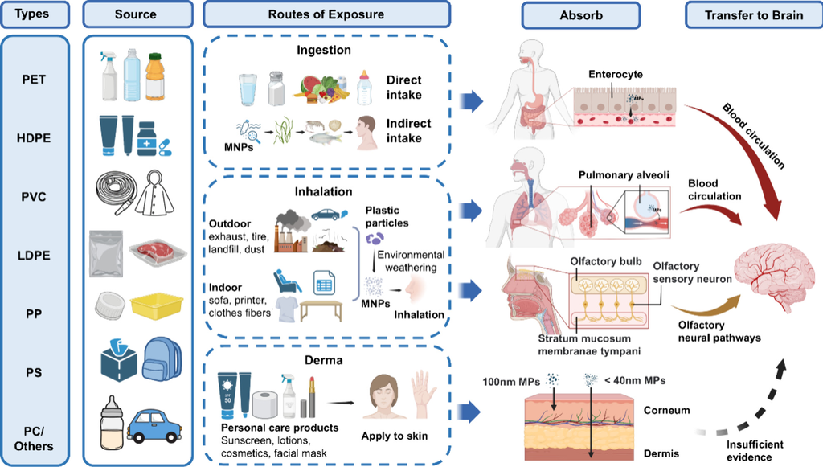

Fig. 1: **Environmental Sources and MNPs’ Pathways to the Brain.** This diagram showcases the types of plastics, where they come from, and how they enter the body. Nanoplastics are best at traversing through the BBB into the brain due to their diminutive size. The SPI code, created by the American Plastics Industry Association, provides a standard method for classifying plastics. Reprinted from Ma Q, Lei J, Pang Y, Shen Y, Zhang T [3].

## Blood-Brain Barrier Structure

The CNS has a sophisticated shield called the Blood-Brain Barrier (BBB) that separates brain matter from the rest of the body. This structure is formed by specialized cerebral endothelial cells connected by tight junctions, along with pericytes and astrocytes [4]. The BBB effectively limits the passage of foreign substances, pathogens, and large molecules from the circulatory system into the brain, which helps maintain the neural microenvironment’s homeostasis.

## Translocation Hypotheses

There are many hypotheses regarding the MNPs’ route through the BBB. One such route is paracellular diffusion, which in theory could allow even the smallest nanoplastic particles to pass, although this pathway is heavily restricted [5,6]. A more probable mechanism is endocytosis, where NPs are internalized by the brain endothelial cells and subsequently exocytosed into the brain interstitial fluid [7]. A third, highly discussed hypothesis is the “Trojan Horse effect”. This scenario presumes that MNPs are first phagocytized by circulating immune cells, which then act as vectors to carry them across the BBB [8].

## Associated Toxicants

A critical factor that exacerbates MNP-related neurotoxicity is associated toxicants. MNPs, due to their high surface-to-volume ratio, readily absorb chemical additives and environmental pollutants, e.g., benzo[a]pyrene, and okadaic acid [9]. These chemicals also have the capability to disrupt the BBB and impair tight junction integrity, thereby allowing the plastic particles easier access to the brain tissue and synergizing the overall neurotoxic effect. [10].

# Microglial Activation and Neuroinflammation

## The Role of Microglia

Microglial cells are the brain’s resident macrophages and the primary immune cells of the CNS. In their resting state, microglia adopt a branched morphology, actively surveying the microenvironment for pathogens, damaged cells, or misfolded proteins [11]. When activated, these cells will rapidly undergo functional and morphological transformation, proliferate, migrate to the injury site, and engage in immunological activities—i.e., phagocytosis, antigen presentation, and the release of signaling molecules [12]. Fig. 2 showcases different transformations of microglial cells. The neuroinflammation is marked by chronic, uncontrolled activation of cells like microglia, which leads to persistent neurotoxicity and neuronal damage [13].

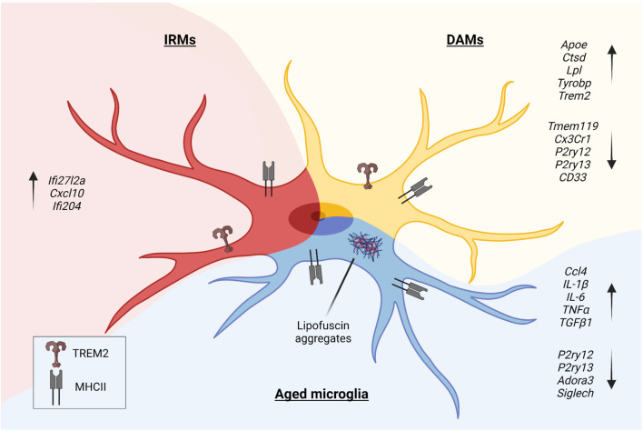

Fig. 2: **Different Activation States of Microglia**. Microglia experience morphologic and phenotypic/functional changes upon activation. Shown in this drawing are Disease-Associated Microglia (DAMs), Injury-Responsive Microglia (IRMs), and aged microglia, each representing a distinct activation state. Reprinted from Muzio L, Viotti A, Martino G [13].

## Direct Activation Mechanism

One primary hypothesized mechanism involves the direct interaction of MNPs with microglia. As discussed in the previous section, NPs are believed to be capable of crossing the BBB and being taken up via phagocytosis. Being non-degradable, these particles persist within the microglial lysosome, which leads to a phenomenon coined “frustrated phagocytosis” [14]. The inability to clear the foreign material results in chronic lysosomal stress and damage—akin to choking themselves to death [15]. Persistent internal stress like this drives a sustained microglial activation state that remains even in the absence of a live pathogen.

## Inflammasome Pathway

As a direct consequence of frustrated phagocytosis, an important inflammatory cascade is triggered: the NLRP3 Inflammasome. This complex is an intracellular receptor that senses danger signals, such as lysosomal rupture and the formation of reactive oxygen species, which are both outcomes of MP/NP internalisation. Activation of the NLRP3 inflammasome leads to the cleavage of pro-caspase-1 into active caspase-1. This activated enzyme, in turn, causes the maturation and release of pro-inflammatory cytokines, namely, Interleukin-1$\beta$ (IL-1$\beta$) and Interleukin-18 (IL-18) [16,17]. These cytokines further propagate the inflammatory signal, recruiting additional immune cells and intensifying the neuroinflammatory cycle—contributing directly to neuronal injury [18].

## Indirect Disruption via Gut-Brain Axis

Microglial activation does not require direct entry of plastic particles into the brain. Exposure in peripheral sites, particularly the gut (via ingestion) and the lungs (via inhalation), can be sufficient to drive a state of systemic inflammation. As MNPs invade and damage the intestinal and pulmonary barriers, gut bacteria and associated toxins will translocate into the bloodstream. This systemic inflammatory state results in the establishment of the GBA [19]. As such, inflammatory signals (such as pro-inflammatory cytokines), even without crossing the BBB themselves, can signal through endothelial cells and other immune cells, or directly diffuse across the BBB, practically acting as “danger messages” that trigger an indirect, secondary activation of the quiescent microglial population and extend the peripheral damage into the CNS [20,21]. Fig. 3 demonstrates this complicated cascade, alongside the GBA.

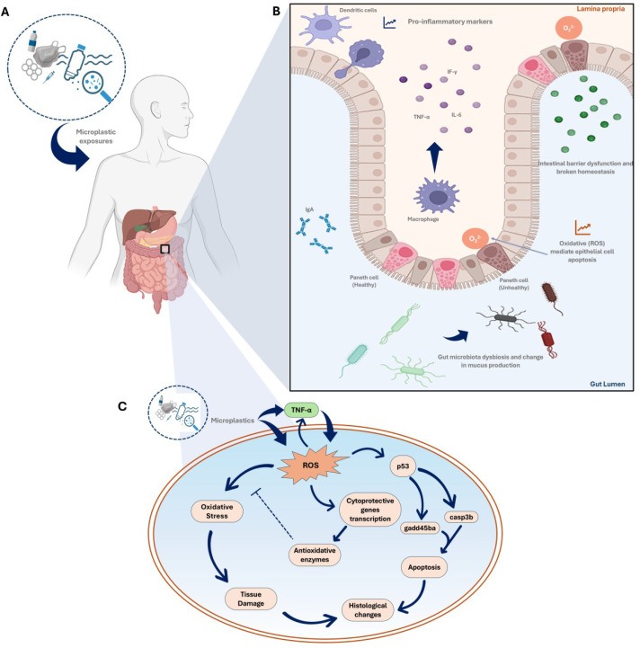

Fig. 3: **Interactions Between MNPs and Human Gut**. Figure (A) shows the entry of MNPs into the body. Figure (B) is the inflammatory response caused by the invasion of MNPs—marked by the release of pro-inflammatory cytokines such as TNF-$\alpha$ and IL-6. Figure (C) outlines the pathways of oxidative stress activated by MNP-induced inflammation. Reprinted from Bora S, Gogoi R, Sharma MR, Anshu, Borah MP, Deka P [20].

# Consequences and Future Directions

## Observed Functional Consequences

Chronic microglial activation, sustained by MNP presence or systemic inflammatory signaling, disrupts the delicate balance required for optimal neural network function. Functionally, this has been observed in animal models to cause behavior changes—such as heightened levels of anxiety and depression-like behaviors [22,23]. This also directly impairs synaptic plasticity and neurogenesis, leading to noticeable performance deficits, particularly in tasks related to learning and memory [24,25]. These alarming outcomes suggest that MNPs contamination poses a risk to neurological health that extends beyond localized damage and impacts complex CNS functions.

## HPA Axis and Stress Hormones

Another significant systemic consequence of chronic inflammation is the disruption of the hypothalamic-pituitary-adrenal (HPA) axis, often termed the Stress Axis. Pro-inflammatory cytokines released during MNP exposure, such as TNF-$\alpha$ and IL-6, are known stimulators of the HPA axis, which lead to increased production and release of glucocorticoids, namely, cortisol [26]. While an initial cortical surge is protective, exposure to inflammation signals over a long time period results in HPA dysregulation—which manifests as either hyper-activation or, paradoxically, a state of hyporesponsiveness. This impaired feedback mechanism compromises the body’s ability to manage stress and inflammation effectively, becoming a debilitating cycle where chronic inflammation leads to HPA axis exhaustion, which in turn further impairs the immune system’s ability to self-regulate [27,28]. This cycle can be seen in Fig. 4.

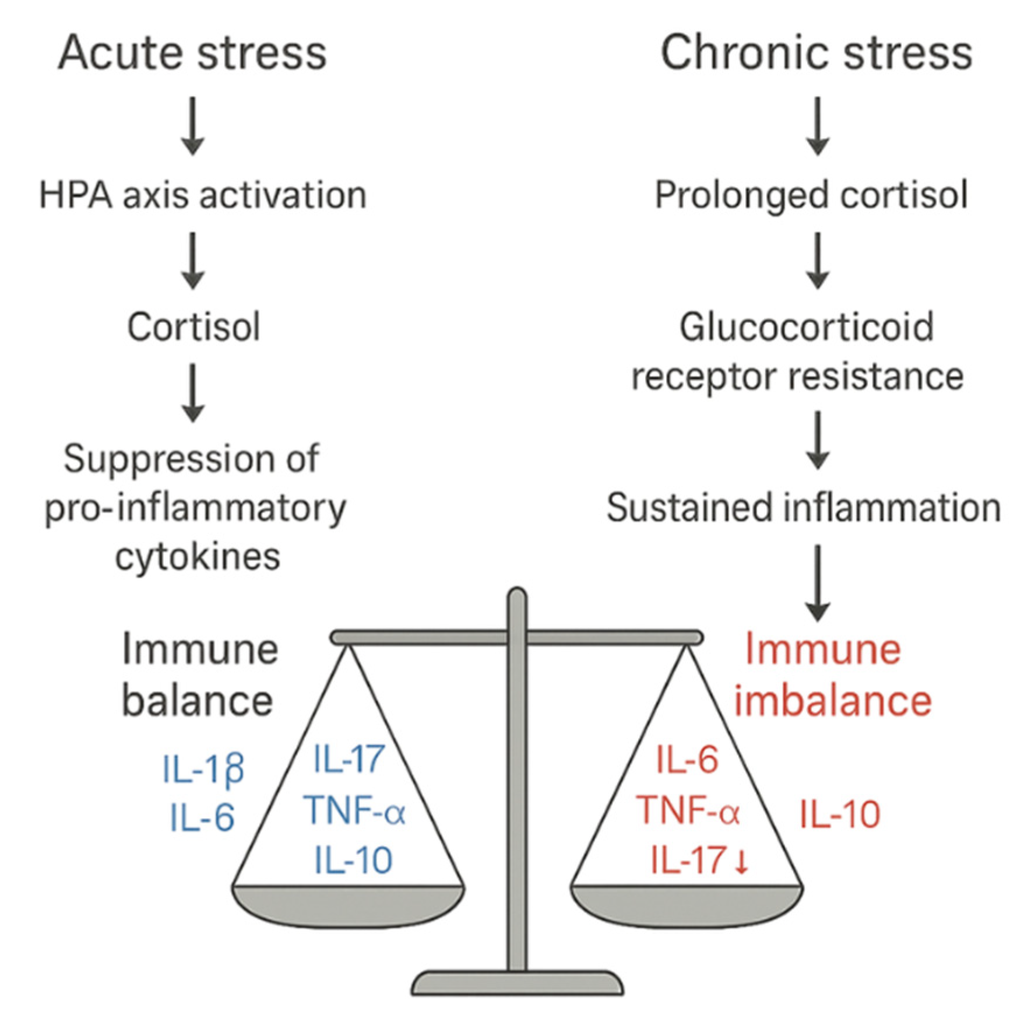

Fig. 4: **MNP-driven HPA Axis Dysregulation Cycle**. The shift from a protective acute stress response (Left) to chronic endocrine and immune dysregulation (Right), a process exacerbated by sustained inflammatory signals from MNP exposure. During acute stress, the HPA axis releases Cortisol which maintains immune homeostasis by restraining pro-inflammatory cytokines (IL-1$\beta$, IL-6, TNF-$\alpha$, IL-17). However, chronic MNP-induced inflammation leads to persistent HPA activation, resulting in Glucocorticoid Receptor resistance. This impaired feedback loop prevents effective immune suppression, thereby sustaining high levels of pro-inflammatory cytokines, driving chronic inflammation—and potentially autoimmunity. Reprinted from Nunez SG, Rabelo SP, Subotic N, Caruso JW, Knezevic NN [28].

## Treatment and Prevention Angle

Micro- and nanoplastic (MNP) exposure is a modern, global issue that requires an urgent, dual strategy: prevention alongside treatment. Prevention is paramount, focusing on policy changes to maximally reduce plastic production and subsequent environmental dispersal. Simultaneously, new technologies must be developed for environmentally-friendly alternatives and plastic remediation. From a biomedical standpoint, targeted treatment strategies could involve developing specific anti-inflammatory agents that target known microglial activation pathways, such as selective inhibitors of the NLRP3 Inflammasome. Such interventions could potentially decouple inflammatory signaling from the physical presence of non-degradable particles.

## Conclusion & Future Research

The evidence and analysis presented here demonstrate that MNPs are more than environmental contaminants—they are also significant neurotoxic agents, capable of long-term harm to both humans and animals alike. Their ubiquitous presence, combined with the alarming capability of nanoplastics to traverse biological barriers establishes a grave threat to CNS health. A sustained neuroinflammatory state caused by frustrated phagocytosis, NLRP3 inflammasome activation, and HPA axis dysregulation manifests as behavioral deficits and cognitive impairment. This proves that MNP exposure extends far beyond localized cellular damage.

Moving forward, a multi-disciplinary approach is crucial to translate these mechanistic findings into actionable public health strategies. Future research should work on large-scale human epidemiological studies to correlate MNP body burden with specific neurological and cognitive outcomes. There is also an urgent need for targeted therapeutic development focused on decoupling inflammatory signaling from the presence of non-degradable particles; BBB-permeable NLRP3 Inflammasome inhibitors should be a good starting point. Further mechanistic work must precisely characterize the inflammatory signals that transmit neurotoxicity from the peripheral gut to the CNS, in order to identify specific signaling molecules that trigger secondary microglial activation. Finally, to accurately reflect real-world exposure, future investigations must move beyond pristine polystyrene and prioritize the toxicity assessment of environmentally-aged and chemically-altered MNPs. While targeted biomedical interventions offer hope, the most effective long-term solution is proactive, globally-coordinated prevention to dramatically reduce plastic production and environmental dissemination.

# Abbreviations

| Abbreviation | Full Term |
| --- | --- |
| **BBB** | Blood-Brain Barrier |
| **CNS** | Central Nervous System |
| **GBA** | Gut-Brain-Axis |
| **HPA** | Hypothalamic-Pituitary-Adrenal |
| **IL-1**$\beta$ | Interleukin-1$\beta$ |
| **IL-6** | Interleukin-6 |
| **IL-18** | Interleukin-18 |
| **MNPs** | Micro- and Nanoplastics |
| **MPs** | Microplastics |
| **NPs** | Nanoplastics |
| **TNF-**$\alpha$ | Tumor Necrosis Factor-$\alpha$ |

# Declaration of Competing Interest

The author declares no competing interests.

# Data/Code Availability

The Quarto project underlying this paper—including the manuscript, figures, and bibliography—is available at https://github.com/ht2905/microplastic-neurotoxicity-paper.

## References

[1]

Thompson RC, Olsen Y, Mitchell RP, Davis A, Rowland SJ, John AWG, et al. Lost at Sea: Where Is All the Plastic? Science 2004;304:838–8. https://doi.org/10.1126/science.1094559.

[2]

Kopatz V, Wen K, Kovács T, Keimowitz AS, Pichler V, Widder J, et al. Micro- and Nanoplastics Breach the Blood–Brain Barrier (BBB): Biomolecular Corona’s Role Revealed. Nanomaterials 2023;13:1404. https://doi.org/10.3390/nano13081404.

[3]

Ma Q, Lei J, Pang Y, Shen Y, Zhang T. Neurotoxicity of Micro- and Nanoplastics: A Comprehensive Review of Central Nervous System Impacts. Environ Health 2025. https://doi.org/10.1021/envhealth.5c00087.

[4]

McConnell HL, Mishra A. Cells of the Blood-brain Barrier: An Overview of the Neurovascular Unit in Health and Disease. Methods Mol Biol 2022;2492:3–24. https://doi.org/10.1007/978-1-0716-2289-6_1.

[5]

Campbell CSJ, Contreras-Rojas LR, Delgado-Charro MB, Guy RH. Objective assessment of nanoparticle disposition in mammalian skin after topical exposure. Journal of Controlled Release 2012;162:201–7. https://doi.org/10.1016/j.jconrel.2012.06.024.

[6]

Winiarska E, Jutel M, Zemelka-Wiacek M. The potential impact of nano- and microplastics on human health: Understanding human health risks. Environmental Research 2024;251:118535. https://doi.org/10.1016/j.envres.2024.118535.

[7]

Hamed M, Martyniuk CJ, Naguib M, Lee J-S, Sayed AE-DH. Neurotoxic effects of different sizes of plastics (nano, micro, and macro) on juvenile common carp (Cyprinus carpio). Front Mol Neurosci 2022;15. https://doi.org/10.3389/fnmol.2022.1028364.

[8]

Li X, Hu S, Yu Z, He F, Zhao X, Liu R. New Evidence for the Mechanisms of Nanoplastics Amplifying Cadmium Cytotoxicity: Trojan Horse Effect, Inflammatory Response, and Calcium Imbalance. Environ Sci Technol 2025;59:9471–85. https://doi.org/10.1021/acs.est.5c01254.

[9]

Yan L, Yu Z, Lin P, Qiu S, He L, Wu Z, et al. Polystyrene nanoplastics promote the apoptosis in Caco-2 cells induced by okadaic acid more than microplastics. Ecotoxicology and Environmental Safety 2023;249:114375. https://doi.org/10.1016/j.ecoenv.2022.114375.

[10]

Cheng S, Ye Z, Wang X, Lian C, Shang Y, Liu H. The effects of adsorbed benzo(a)pyrene on dynamic behavior of polystyrene nanoplastics through phospholipid membrane: A molecular simulation study. Colloids and Surfaces B: Biointerfaces 2023;224:113211. https://doi.org/10.1016/j.colsurfb.2023.113211.

[11]

Wake H, Moorhouse AJ, Nabekura J. Functions of microglia in the central nervous system – beyond the immune response. Neuron Glia Biology 2011;7:47–53. https://doi.org/10.1017/S1740925X12000063.

[12]

Yang I, Han SJ, Kaur G, Crane C, Parsa AT. The Role of Microglia in Central Nervous System Immunity and Glioma Immunology. J Clin Neurosci 2010;17:6–10. https://doi.org/10.1016/j.jocn.2009.05.006.

[13]

Muzio L, Viotti A, Martino G. Microglia in Neuroinflammation and Neurodegeneration: From Understanding to Therapy. Front Neurosci 2021;15:742065. https://doi.org/10.3389/fnins.2021.742065.

[14]

Ishida T, Fujihara N, Nishimura T, Funabashi H, Hirota R, Ikeda T, et al. Live-cell imaging of macrophage phagocytosis of asbestos fibers under fluorescence microscopy. Genes Environ 2019;41:14. https://doi.org/10.1186/s41021-019-0129-4.

[15]

Mularski A, Marie-Anaïs F, Mazzolini J, Niedergang F. Observing Frustrated Phagocytosis and Phagosome Formation and Closure Using Total Internal Reflection Fluorescence Microscopy (TIRFM). Methods Mol Biol 2018;1784:165–75. https://doi.org/10.1007/978-1-4939-7837-3_16.

[16]

Harrison C. Chiasma and Roche partner in oral peptide drug delivery. Nature Reviews Drug Discovery 2013;12:255–5. https://doi.org/10.1038/nrd3989.

[17]

Matousek SB, Ghosh S, Shaftel SS, Kyrkanides S, Olschowka JA, O’Banion MK. Chronic IL-1$\beta$-mediated neuroinflammation mitigates amyloid pathology in a mouse model of Alzheimer’s disease without inducing overt neurodegeneration. J Neuroimmune Pharmacol 2012;7:156–64. https://doi.org/10.1007/s11481-011-9331-2.

[18]

Delantoni A, Sarafopoulos A, Giannouli N, Rafailidis V. Maxillofacial inflammations visualized with ultrasonography. Description of the imaging features and literature review based on a characteristic case series. J Ultrason 2023;23:e80–9. https://doi.org/10.15557/jou.2023.0015.

[19]

Kalyan M, Tousif AH, Sonali S, Vichitra C, Sunanda T, Praveenraj SS, et al. Role of Endogenous Lipopolysaccharides in Neurological Disorders. Cells 2022;11:4038. https://doi.org/10.3390/cells11244038.

[20]

Bora SS, Gogoi R, Sharma MR, Anshu, Borah MP, Deka P, et al. Microplastics and human health: Unveiling the gut microbiome disruption and chronic disease risks. Front Cell Infect Microbiol 2024;14:1492759. https://doi.org/10.3389/fcimb.2024.1492759.

[21]

Hoogland ICM, Houbolt C, van Westerloo DJ, van Gool WA, van de Beek D. Systemic inflammation and microglial activation: Systematic review of animal experiments. J Neuroinflammation 2015;12:114. https://doi.org/10.1186/s12974-015-0332-6.

[22]

Chen L, Zeng L, Li W, Li J-S. The Activation of Hippocampal Microglial Cells and Their Role in the Regulation of Pain. Journal of Integrative Neuroscience 2025;24:27730. https://doi.org/10.31083/jin27730.

[23]

Fang S, Wu Z, Guo Y, Zhu W, Wan C, Yuan N, et al. Roles of microglia in adult hippocampal neurogenesis in depression and their therapeutics. Front Immunol 2023;14. https://doi.org/10.3389/fimmu.2023.1193053.

[24]

Cornell J, Salinas S, Huang H-Y, Zhou M. Microglia regulation of synaptic plasticity and learning and memory. Neural Regen Res 2021;17:705–16. https://doi.org/10.4103/1673-5374.322423.

[25]

Bollinger JL, Wohleb ES. The formative role of microglia in stress-induced synaptic deficits and associated behavioral consequences. Neurosci Lett 2019;711:134369. https://doi.org/10.1016/j.neulet.2019.134369.

[26]

Jeon SW, Kim YK. Neuroinflammation and cytokine abnormality in major depression: Cause or consequence in that illness? World Journal of Psychiatry 2016;6:283–93. https://doi.org/10.5498/wjp.v6.i3.283.

[27]

Bertollo AG, Santos CF, Bagatini MD, Ignácio ZM. Hypothalamus-pituitary-adrenal and gut-brain axes in biological interaction pathway of the depression. Front Neurosci 2025;19. https://doi.org/10.3389/fnins.2025.1541075.

[28]

Nunez SG, Rabelo SP, Subotic N, Caruso JW, Knezevic NN. Chronic Stress and Autoimmunity: The Role of HPA Axis and Cortisol Dysregulation. International Journal of Molecular Sciences 2025;26:9994. https://doi.org/10.3390/ijms26209994.